# 04-PresentationPlots

Carlos Mercado

April 30, 2020

## Lesson 4

Lesson 4 is to leverage a new package- ggplot2 to make plots that are presentation-ready for clients.

Tasks are:

1. Use our updated version of accidents (i.e. no NAs and Bottom/Top coded) from Lesson 3 to identify seasonality in accidents at the monthly level. To do this we must aggregate the date of stop to the monthly level. We can use the lubridate package to help us extract the month and year from each Date of Stop to form a new MonthYear of stop column.

HINT: be careful with the class of your MonthYear column. Consider using “MM-01-YYYY” format to keep it as a Date.

Also, you may want to make new datasets that are easier to work with. For example, here I aggregate my accidents data to be:

MonthYear | Number of Accidents | Number of Fatalities | Number of Alcohol

This is not strictly required to do the plotting, but learning to reshape data in a programmatic way is an important skill!

Some functions you may want to look into include: table, data.frame, as.data.frame, transpose (the t() function), as.vector(), and of course subsetting such as x[5, 9] (5th row, 9th column of data table x).

It may also benefit you to practice paste0 or even use the dplyr package which has a lot of great functions and good documentation. Functions like summarize in that package, or aggregate() in base R can all be used to help you. If you do choose to coerce anything to class Date, be careful to research the “format” argument.

This lesson is the hardest one and took me a lot of googling to do myself!

2. We want to include a 3rd dimension: whether alcohol was involved in the accident. We can do that either by *sizing* or *coloring* our points based on how many accidents involved alcohol in that month (if any).
3. We can add extra emphasis to the months where there was a fatality as well.

Remember to use ggplot2() a practice with the aes() argument. Use geom_point and geom_smooth as you see fit to identify if there is a trend.

BONUS: make your own plot and a narrative of that plot to share with others.

## Check Yourself

1. Which months contained fatalities?
2. Which months had accidents involving alcohol?
3. Which months had both a fatality and involved alcohol?

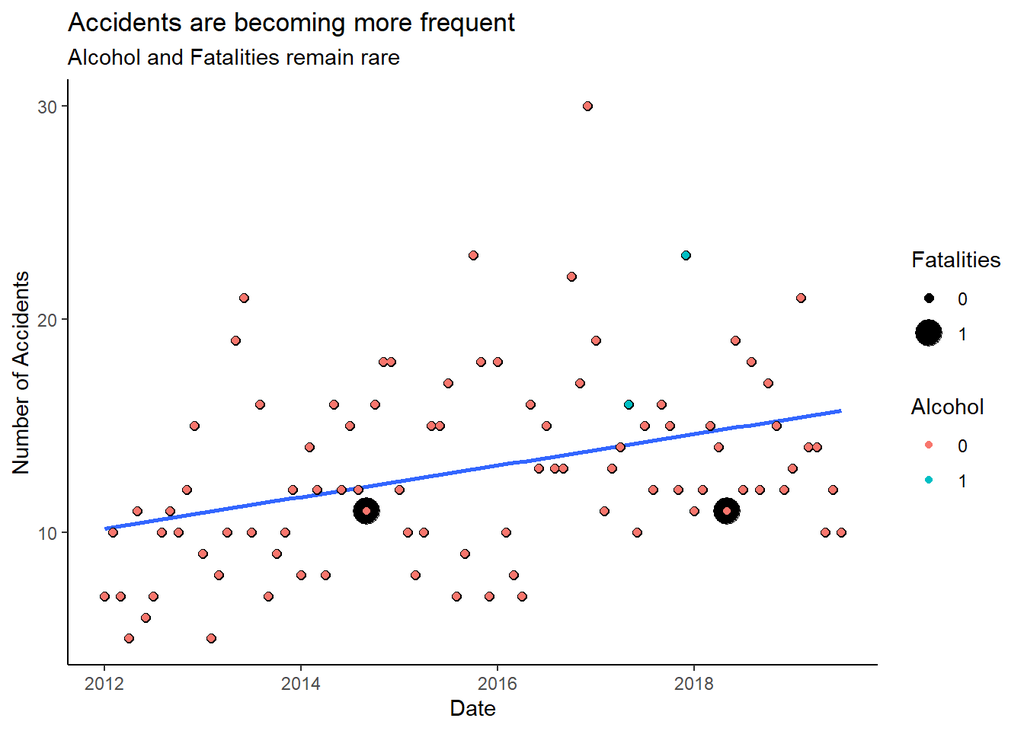